# Task 3: Text wrangling and analysis

Grace Brofman

2/18/2021

### **Introduction:**

For this task I used an unsavory and perhaps sexist magazine I found on the [(Internet Archive)](https://archive.org/details/texts). I chose to perform a sentiment analysis on the 2009 edition of **[(Just for Girls and Guys Youth Magazine)](https://archive.org/details/j4g09/page/n15/mode/2up)** by the Human Life Alliance. The first half (pages 1-8) is “just for girls”, while the second half (pages 9-16) is “just for boys”. The two halves are meant to give each side insight into the other gender. I wanted to see how the sentiments differed (if at all) between the “girls’” side and the “boys’” side.

### **Part 1:** Word count visualization

```r
# girl-focused pages are 1-8. boy-focused pages are 9-16.
girl_top_50 <- nonstop_counts %>%
  filter(page == c(1:8)) %>%
  arrange(-n) %>%
  slice(1:50)

boy_top_50 <- nonstop_counts %>%
  filter(page == c(9:16)) %>%
  arrange(-n) %>%
  slice(1:50)

girl_cloud <- ggplot(data = girl_top_50,
                     aes(label = word)) +
  geom_text_wordcloud(aes(color = n, size = n)) +
  scale_size_area(max_size = 8) +
  labs(title = "50 most common words in Just for Girls")


boy_cloud <- ggplot(data = boy_top_50,
                     aes(label = word)) +
  geom_text_wordcloud(aes(color = n, size = n)) +
  scale_size_area(max_size = 8) +
  labs(title = "50 most common words in Just for Boys")
```

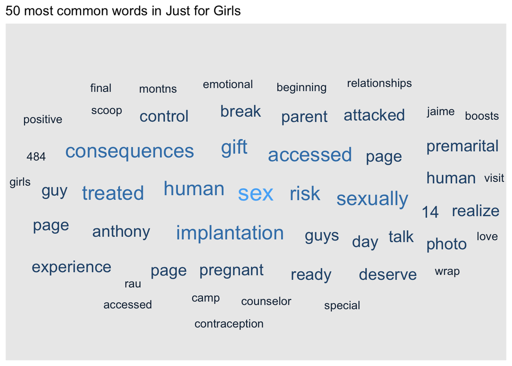

```r
girl_cloud
```

**Figure 1:** Word cloud for the 50 most common words in “Just for Girls”, pages 1-8. Word size is representative of frequency.

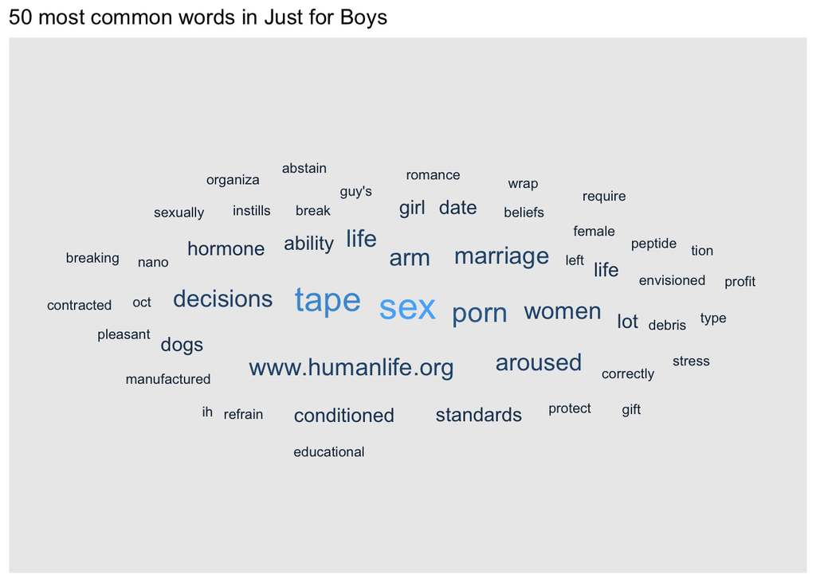

```r
boy_cloud
```

**Figure 2:** Word cloud for the 50 most common words in “Just for Boys”, pages 9-16. Word size is representative of frequency.

### **Part 2:** Sentiment analysis

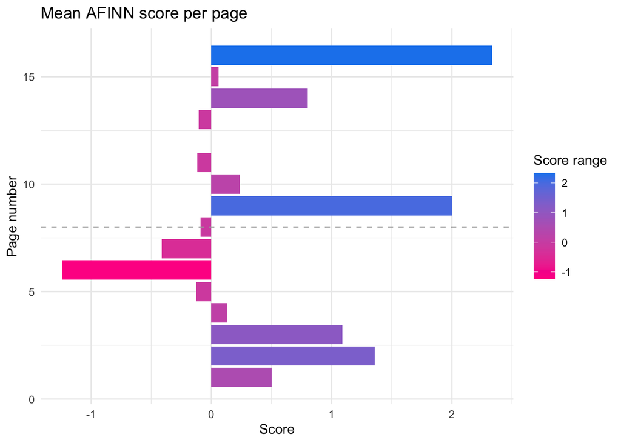

```r
# sentiment analysis using AFINN lexicon
mag_afinn <- mag_nonstop_words %>%  # finding common words beteen mag_nonstop_words and afinn lexicon
  inner_join(get_sentiments("afinn"))

# for each page, how many times does each sentiment score show up?
afinn_counts <- mag_afinn %>%
  count(page, value)

afinn_means <- mag_afinn %>%
  group_by(page) %>%
  summarize(mean_afinn = mean(value))

plot_2 <- ggplot(data = afinn_means,
       aes(x = page,
           y = mean_afinn)) +
  geom_col(aes(fill = mean_afinn)) +
  scale_fill_gradient(low = "deeppink",
  high = "dodgerblue2") +
  geom_vline(xintercept = 8, linetype = "dashed", color = "darkgray") +
  labs(x = "Page number", y = "Score", title = "Mean AFINN score per page", fill = "Score range") +
  coord_flip() +
  theme_minimal()

plot_2
```

```r
# girl-targeted pages are 1-8, boy-targeted pages are 9-16. it seems that in general, the boy-targeted pages are associated with a higher positivity than the girl-targeted pages
```

**Figure 3:** Sentiment analysis of Just for Girls and Boys Youth Magazine using the AFINN lexicon. Pages 1-8 are “Just for Girls” while pages 9-16 are “Just for Boys”.

### **References**

**Human Life Alliance**. “Just for Girl and Guys Youth Magazine.” 2009: https://archive.org/details/j4g09/mode/2up